# Chapter 24: Model Building

```r
library(pacman)
p_load(tidyverse, modelr, nycflights13, lubridate)
```

## Why are low quality diamonds more expensive?

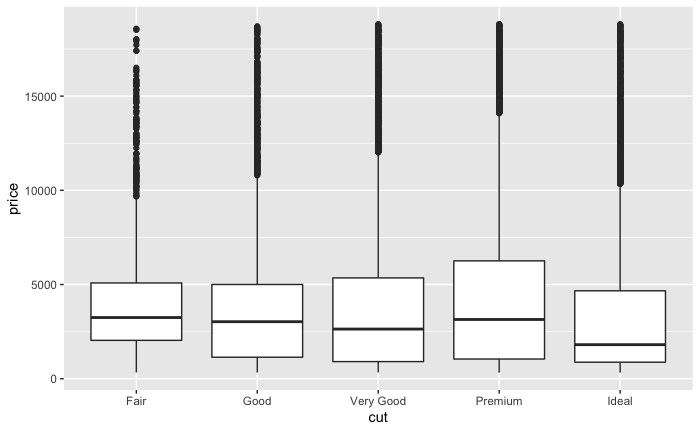

```r
ggplot(diamonds, aes(cut, price)) + geom_boxplot()
```

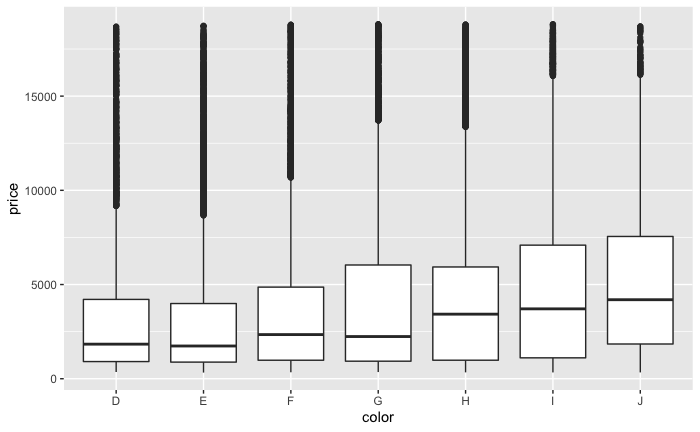

```r
ggplot(diamonds, aes(color, price)) + geom_boxplot()
```

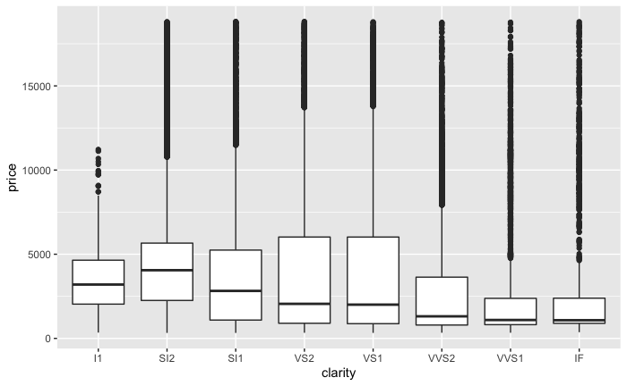

```r
ggplot(diamonds, aes(clarity, price)) + geom_boxplot()
```

### Price and carat

The confounding variable here is weight. Lower quality diamonds tend to be larger.

[figure not shown]

```r
ggplot(diamonds, aes(x = carat, y = price)) +
  geom_hex(bins = 50)
```

We can make it easier to see how the other attributes of a diamond affect its relative price by fitting a model to separate out the effect of carat. We’ll make a couple tweeks first:

1. Focus on diamonds smaller than 2.5 carats
2. Log-transform the carat and price variables

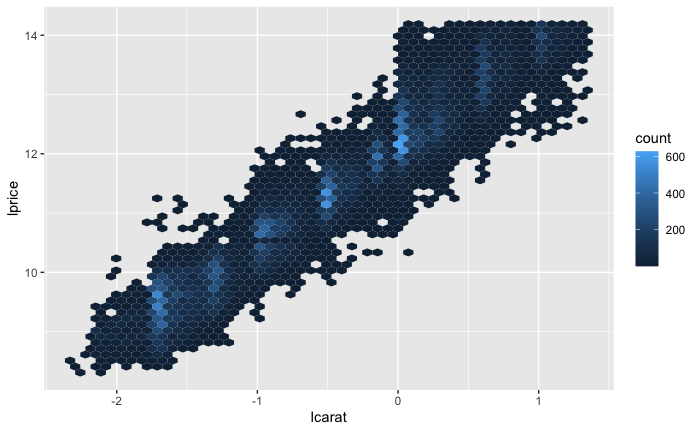

```r
diamonds2 <- diamonds %>%
  filter(carat <= 2.5) %>%
  mutate(lprice = log2(price),
         lcarat = log2(carat))

ggplot(diamonds2, aes(lcarat, lprice)) +
  geom_hex(bins = 50)
```

Then we look at what the model tells us about the data.

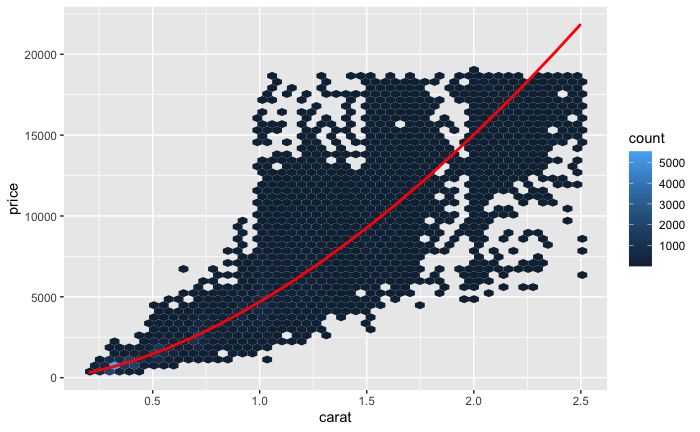

Now we look at the residuals, which verifies that we’ve successfully removed the strong linear pattern:

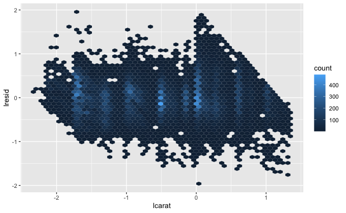

Now we can also re-do our motivating plots using those residuals instead of price:

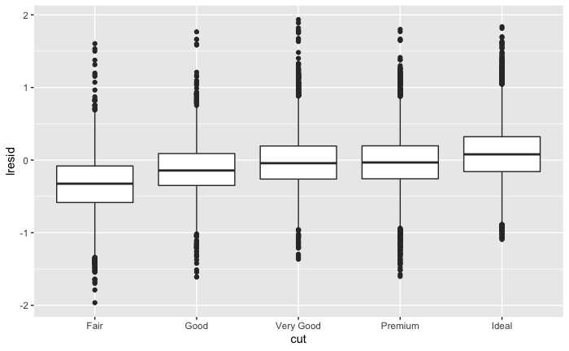

```r
ggplot(diamonds2, aes(cut, lresid)) + geom_boxplot()
```

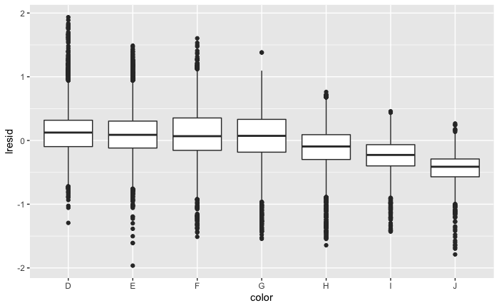

```r
ggplot(diamonds2, aes(color, lresid)) + geom_boxplot()
```

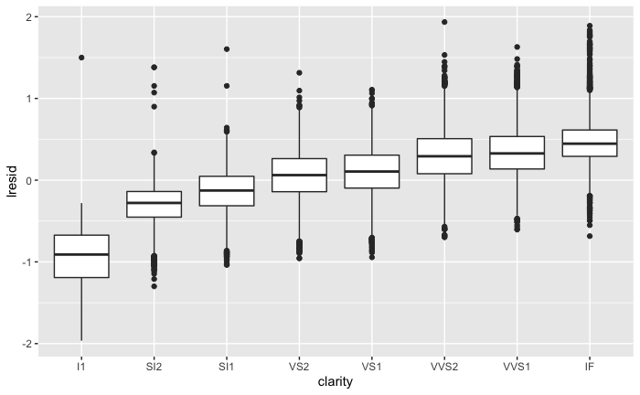

```r
ggplot(diamonds2, aes(clarity, lresid)) + geom_boxplot()
```

Now we see the relationship as we expect: as the quality of the diamond increases, so too does its relative price. To interpret the $y$-axis, we need to think about its units. A residual of -1 indicates that `lprice` was 1 unit lower than a prediction based solely on its weight.

### A more complicated model

```r
mod_diamond2 <- lm(lprice ~ lcarat + color + cut + clarity,
                   data = diamonds2)

summary(mod_diamond2)
```

```
Call:
lm(formula = lprice ~ lcarat + color + cut + clarity, data = diamonds2)

Residuals:
     Min       1Q   Median       3Q      Max
-1.17388 -0.12437 -0.00094  0.11920  2.78322

Coefficients:
             Estimate Std. Error  t value Pr(>|t|)
(Intercept) 12.206978   0.001693 7211.806  < 2e-16 ***
lcarat       1.886239   0.001124 1677.809  < 2e-16 ***
color.L     -0.633998   0.002910 -217.872  < 2e-16 ***
color.Q     -0.137580   0.002676  -51.409  < 2e-16 ***
color.C     -0.022072   0.002503   -8.819  < 2e-16 ***
color^4      0.016570   0.002297    7.213 5.54e-13 ***
color^5     -0.002828   0.002169   -1.304    0.192
color^6      0.003533   0.001971    1.793    0.073 .
cut.L        0.173866   0.003386   51.349  < 2e-16 ***
cut.Q       -0.050346   0.002980  -16.897  < 2e-16 ***
cut.C        0.019129   0.002583    7.407 1.31e-13 ***
cut^4       -0.002410   0.002066   -1.166    0.243
clarity.L    1.308155   0.005179  252.598  < 2e-16 ***
clarity.Q   -0.334090   0.004839  -69.047  < 2e-16 ***
clarity.C    0.178423   0.004140   43.093  < 2e-16 ***
clarity^4   -0.088059   0.003298  -26.697  < 2e-16 ***
clarity^5    0.035885   0.002680   13.389  < 2e-16 ***
clarity^6   -0.001371   0.002327   -0.589    0.556
clarity^7    0.048221   0.002051   23.512  < 2e-16 ***
---
Signif. codes:  0 ‘***’ 0.001 ‘**’ 0.01 ‘*’ 0.05 ‘.’ 0.1 ‘ ’ 1

Residual standard error: 0.1916 on 53795 degrees of freedom
Multiple R-squared:  0.9828,    Adjusted R-squared:  0.9828
F-statistic: 1.706e+05 on 18 and 53795 DF,  p-value: < 2.2e-16
```

```r
grid <- diamonds2 %>%
  data_grid(cut, .model = mod_diamond2) %>%
  add_predictions(mod_diamond2)

grid
```

| cut | lcarat | color | clarity | pred |
| --- | --- | --- | --- | --- |
| Fair | -0.5145732 | G | VS2 | 11.20557 |
| Good | -0.5145732 | G | VS2 | 11.32050 |
| Very Good | -0.5145732 | G | VS2 | 11.37396 |
| Premium | -0.5145732 | G | VS2 | 11.40627 |
| Ideal | -0.5145732 | G | VS2 | 11.43759 |

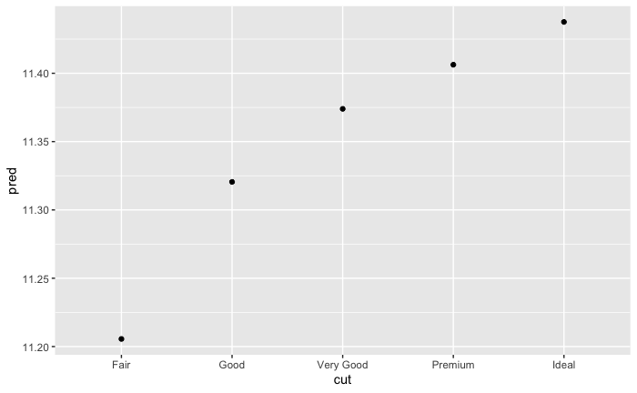

```r
ggplot(grid, aes(cut, pred)) +
  geom_point()
```

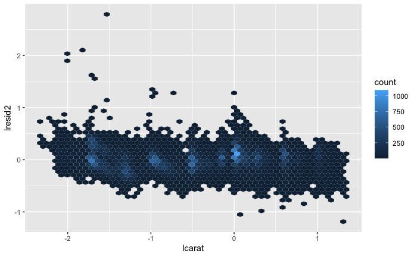

Some diamonds have large residuals - a residual of 2 indicates that the diamond is 4x the price that we expected. It can be helpful to look at the residuals for these individually:

| price | pred | carat | cut | color | clarity | depth | table | x | y | z |
| --- | --- | --- | --- | --- | --- | --- | --- | --- | --- | --- |
| 1013 | 264 | 0.25 | Fair | F | SI2 | 54.4 | 64 | 4.30 | 4.23 | 2.32 |
| 1186 | 284 | 0.25 | Premium | G | SI2 | 59.0 | 60 | 5.33 | 5.28 | 3.12 |
| 1186 | 284 | 0.25 | Premium | G | SI2 | 58.8 | 60 | 5.33 | 5.28 | 3.12 |
| 1262 | 2644 | 1.03 | Fair | E | I1 | 78.2 | 54 | 5.72 | 5.59 | 4.42 |
| 1415 | 639 | 0.35 | Fair | G | VS2 | 65.9 | 54 | 5.57 | 5.53 | 3.66 |
| 1415 | 639 | 0.35 | Fair | G | VS2 | 65.9 | 54 | 5.57 | 5.53 | 3.66 |
| 1715 | 576 | 0.32 | Fair | F | VS2 | 59.6 | 60 | 4.42 | 4.34 | 2.61 |
| 1776 | 412 | 0.29 | Fair | F | SI1 | 55.8 | 60 | 4.48 | 4.41 | 2.48 |
| 2160 | 314 | 0.34 | Fair | F | I1 | 55.8 | 62 | 4.72 | 4.60 | 2.60 |
| 2366 | 774 | 0.30 | Very Good | D | VVS2 | 60.6 | 58 | 4.33 | 4.35 | 2.63 |

[output cut: 6 more lines]

### Exercises

1. In the plot of `lcarat` vs. `lprice`, there are some bright vertical strips. What do they represent?

   They represent diamonds of the same size that have a range of prices.
2. If `log(price) = a_0 + a_1 * log(carat)`, what does that say about the relationship between `price` and `carat`?
3. Extract the diamonds that have very high and very low residuals. Is there anything unusual about these diamonds? Are they particularly bad or good, or do you think these are pricing errors?
4. Does the final model, `mod_diamond2`, do a good job of predicting diamond prices? Would you trust it to tell you how much to spend if you were buying a diamond?